# Benchmarking R packages for Calculation of Persistent Homology

Several persistent homology software libraries have been implemented in R. Specifically, the Dionysus, GUDHI, and Ripser libraries have been wrapped by the **TDA** and **TDAstats** CRAN packages. These software represent powerful analysis tools that are computationally expensive and, to our knowledge, have not been formally benchmarked. Here, we analyze runtime and memory growth for the 2 R packages and the 3 underlying libraries. We find that datasets with less than 3 dimensions can be evaluated with persistent homology fastest by the GUDHI library in the **TDA** package. For higher-dimensional datasets, the Ripser library in the TDAstats package is the fastest. Ripser and **TDAstats** are also the most memory-efficient tools to calculate persistent homology.

Eashwar V. Somasundaram (Case Western Reserve University) , Shael E. Brown (McGill University) , Adam Litzler (Department of Translational Hematology and Oncology Research, Cleveland Clinic Foundation) , Jacob G. Scott (Department of Translational Hematology and Oncology Research, Cleveland Clinic Foundation) , Raoul R. Wadhwa (Case Western Reserve University)  
2021-06-07

## 1 Introduction

Topological data analysis (TDA) is a broad set of methodologies that characterizes structural features of datasets inspired by topological principles. It has a broad range of usage, from viral evolution to physical chemistry (Chan et al. 2013; Offroy and Duponchel 2016). Within the umbrella of TDA, persistent homology represents an algebraic approach to understanding the number, characteristics, and persistence of structural features in an $n$-dimensional point cloud. In the basic workflow of persistent homology, a series of simplicial complexes are generated on point clouds to characterize topological features. There are several methods to generate these complexes on point clouds. In this paper, we focus on persistent homology of the Vietoris-Rips and alpha complexes, which use simplicial complexes to approximate topologic relationships in point clouds. The exact method of constructing these complexes is described in the Mathematics section. Essentially, we measure features that are discovered by the algorithm at a particular stage and disappear at a later stage. The difference between these stages is persistence. Features with larger persistence more likely represent real geometric patterns rather than noise.

There are several C++ libraries available to researchers that calculate alpha and Vietoris-Rips complexes, such as Dionysus, GUDHI, and Ripser (Maria et al. 2016; Morozov 2018; Bauer 2019). These libraries have been wrapped in R by the [*TDA*](https://CRAN.R-project.org/package=TDA) and [*TDAstats*](https://CRAN.R-project.org/package=TDAstats) packages (Wadhwa et al. 2018; Fasy et al. 2019). Although useful, calculating persistent homology for large datasets is often limited due to computational complexity (Otter et al. 2017). As a result, researchers often limit persistent homology analysis to lower dimensions. However, ignoring features in higher dimensions may cause significant information loss, underutilizing persistent homology’s capabilities. Here, we aim to benchmark two R packages - [*TDA*](https://CRAN.R-project.org/package=TDA) and [*TDAstats*](https://CRAN.R-project.org/package=TDAstats) - and enable researchers to most efficiently calculate persistent homology in R.

## 2 Mathematics of Persistent Homology

An $n$-dimensional simplex is the convex hull of $n+1$ points in a Euclidean space. More intuitively, an $n$-dimensional simplex is the simplest $n$-dimensional object (e.g., a 0-simplex is a point, a 1-simplex is a line, a 2-simplex is a triangle, 3-simplex is a tetrahedron). These simplices can be glued together on common sub-simplices to form a simplicial complex (e.g., two triangles sharing a common side). In a simplicial complex, topological features will arise that can be characterized by Betti numbers. Each Betti number, denoted by $B_k$, $k$ counts the number of features in dimension $k$. $B_0$ counts the number of connected components, $B_1$ counts refer to loops, $B_2$ counts the number of voids, and so on (Edelsbrunner and Harer 2008).

There are several different methods to construct a simplicial complex on a given point cloud $S$, but this paper focuses on the Vietoris-Rips and alpha complexes. The Vietoris-Rips complex is perhaps the most common method for constructing a simplicial complex to calculate persistent homology (Hausmann 1996). In a point cloud of $k$ points in 2 dimensions, a distance parameter, $\delta > 0$, can be used to draw a circle of diameter $\delta$ around every point in $S$. For point clouds in 3 dimensions, spheres of diameter $\delta$ are drawn around each point. For dimensions $k$ greater than 3, a $k$-dimensional hypersphere is drawn around each point. The remainder of this explanation will focus on the 2-dimensional case. If $\delta$ is sufficiently large, then some of the resulting circles may intersect. In this case, a line is drawn to connect the points at the center of the intersecting circles. When a triple of points is connected, we add a triangle (2-simplex). When a quadruple of points are connected, we add a tetrahedron (3-simplex) and so forth. However, we only add simplices at most of the dimension of the space of the point clouds (e.g., only up to 3-simplices are added in a 3-dimensional point cloud). This group of points and lines form the skeleton of a simplicial complex. For each distance parameter, $\delta$, there will be a single simplicial complex associated with it. As $\delta$ increases, different topological features may appear, persist, and eventually disappear.

Once $\delta$ reaches the maximum Euclidean distance between any pair of points in the point cloud, a convex hull will form around all $k$ points creating a $(k-1)$-dimensional simplex. A 3-column matrix can be created recording the dimension of each feature, the $\delta$ at which that feature appeared, and the $\delta$ at which it disappeared. This matrix characterizes the persistent homology of that point cloud.

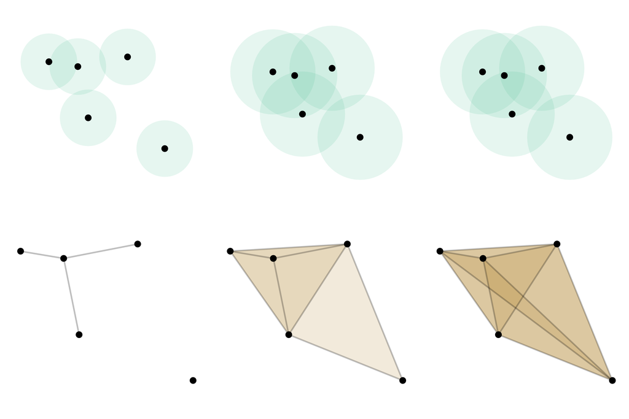

Alpha complexes provide another method to generate simplicial complexes on the point cloud $S$. For alpha complexes, we partition the whole space in which the data resides into cells such that each cell contains exactly one data point $x$, and the cell of that data point is the set of all points closer to $x$ than any other data points. Such a partition is also known as a Voronoi diagram. The nerve of a Voronoi diagram is equivalent to the Delaunay Triangulation (Edelsbrunner and Mücke 1994). Alpha complexes are simplicial complexes that are subsets of the Delaunay Triangulation. The parameter, $\alpha$, can describe the radius of a ball (dimension matches dimension of the space) of each point in the point cloud $S$ much, like $\delta$ describes the diameter of a circle in the Vietoris-Rips complex. We first intersect the $\alpha$ radius balls with their own Voronoi cell and then search for intersections of these subsetted balls to form simplices. Once $\alpha$ is large enough, the full Delaunay Triangulation is formed. In between these stages, the birth and death of features at certain values of $\alpha$ can be captured in a 3-column persistent homology matrix much like the Vietoris-Rips complex. One key difference from the Vietoris-Rips complex is that edges can only form between neighboring points in the alpha complex.

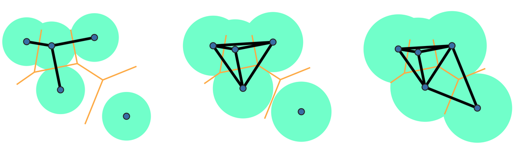

Figure 2: **Basic visualization of the Alpha complex.** For a given $\alpha$, $\alpha$-radius balls are drawn around each point, and the union of the balls is taken. Then, an intersection between this union of $\alpha$-balls and the Vornoi diagram is taken. A connecting segment is drawn between points in adjacent Voronoi cells once the $\alpha$-ball fills out the Voronoi diagram. As $\alpha$ grows, more circles fill out the Voronoi cells. Once $\alpha$ is large enough, the Delaunay Triangulation is formed.

In both methods, the boundary matrix records all simplicial complexes for each parameter value ($\delta$ for Vietoris-Rips complexes and $\alpha$ for alpha complexes). Calculating persistent homology is divided into two steps: (1) forming the boundary matrix and (2) reducing the boundary matrix to be able to read off the topological features of each dimension and their birth/death values of the parameter. The second step can be computed in at most O(k^3) steps, where k is the number of rows (and columns) of the boundary matrix. The size of the boundary matrix can describe the memory complexity on the random access memory (RAM) for persistent homology calculations. We compare memory complexity between alpha and Vietoris-Rips complexes in this paper.

Alpha complex calculations have a run time complexity of $O(n^{d/2})$, and Vietoris-Rips complex calculations have a run time complexity of $O(2^n)$, where $n$ is the number of points and $d$ is the point cloud dimension (Otter et al. 2017). Vietoris-Rips’s run time and memory are exponential with regards to point number (but constant with data dimension) in contrast to alpha complexes where run time and memory are polynomial with point number (but exponential with data dimension). Therefore, we can predict that low dimensional point clouds favor alpha complexes, but fewer points in higher dimension favor Vietoris-Rips complexes.

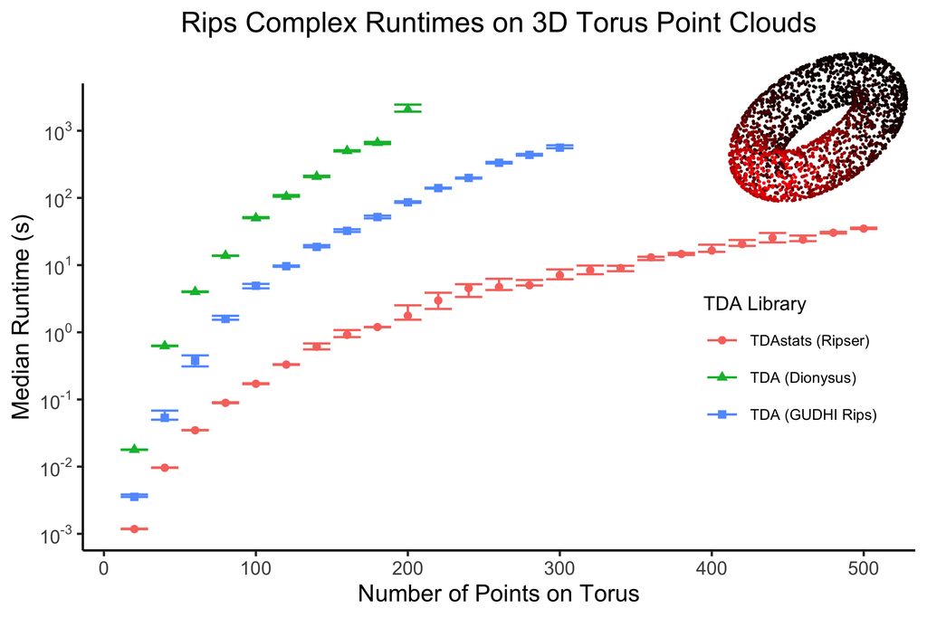

## 3 Methods

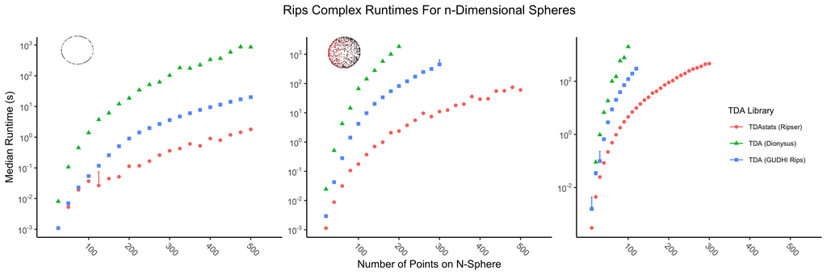

Figure 4: **Calculating persistent homology of round point clouds of varying dimensions with three TDA libraries.** Median runtime (min to max, $n=10$ iterations per data point) for each TDA library (denoted by color) is plotted against point cloud size and faceted by data dimension. The left panel compares library performance for a 2-dimensional circular point cloud, the center panel for a 3-dimensional spherical point cloud, and the right panel for a 4-dimensional hyperspherical point cloud. Maximum feature dimensions (one less than the data dimension) were calculated in each case.

## 4 Results

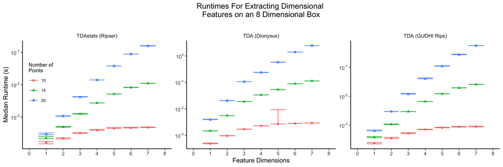

Figure 5: **Comparison of Vietoris-Rips complex persistent homology calculation as a function of feature dimension.** Median runtime (min to max, $n=10$ iterations per data point) for various point cloud sizes (denoted by color) is plotted against the calculated feature dimension and faceted by TDA library. Persistent homology was calculated on a uniformly distributed random sample of points contained within a 1 unit, 8-dimensional cube. Computational limitations of calculating persistent homology for a large number of feature dimensions restricted point clouds to relatively small sizes.

Tori do not trivially generalize to other dimensions, but circles do. Benchmarking on a circular point cloud permits confirmation of the pattern in Figure 3 while also revealing how the libraries compare as the dataset dimension increases. Figure 4 exhibits the resulting data for a 2-dimensional circle (left panel), 3-dimensional sphere (center panel), and 4-dimensional hypersphere (right panel). When the dataset dimension equals 2, GUDHI practically matches Ripser’s performance in outpacing Dionysus. However, in the case of the 3-dimensional sphere, the pattern visualized in Figure 3 for the 3-dimensional torus is again present. By the 4th dimension, the gap between Ripser and GUDHI widens. Of note, missing points for larger datasets in Figure 4 are not plotted if and only if calculating persistent homology caused an error due to insufficient RAM. Thus, for the hypersphere, Ripser was able to calculate persistent homology for a dataset with approximately 3 times as many points as Dionysus and over 2 times as many as GUDHI. Interestingly, all curves plotted in Figure 4 grow polynomially with respect to the number of points (see Supplement for regression details).

Large data and feature dimensionality often restrict persistent homology calculations to small point clouds due to computational limits. When calculating persistent homology on a high-dimensional point cloud, as Vietoris-Rips feature dimension increases, there is a corresponding increase in runtime (Figure 5). Dionysus is clearly outmatched by GUDHI and Ripser as feature dimension increases, with the difference being clearest for larger point clouds; by feature dimension 5, Ripser outpaces GUDHI as well (Figure 5). It is unclear whether runtime for each library grows polynomially or exponentially (see Supplement for regression details).

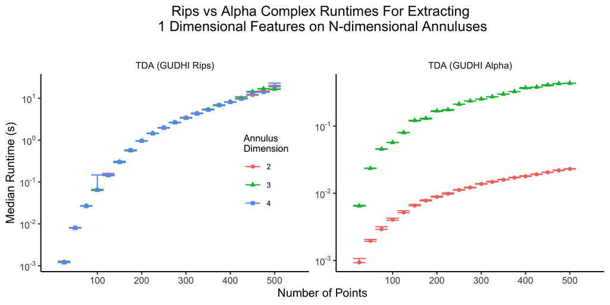

Figure 6: **Comparing persistent homology calculation between Vietoris-Rips and alpha complices.** Median runtime (min to max, $n=10$ iterations per data point) for various data dimensions (denoted by color) are plotted against point cloud size and faceted by type of simplicial complex. Maximum of feature dimension was kept constant at 1. Alpha complex runtimes are linear, in contrast to polynomial Vietoris-Rips runtimes (see Supplement for regression details).

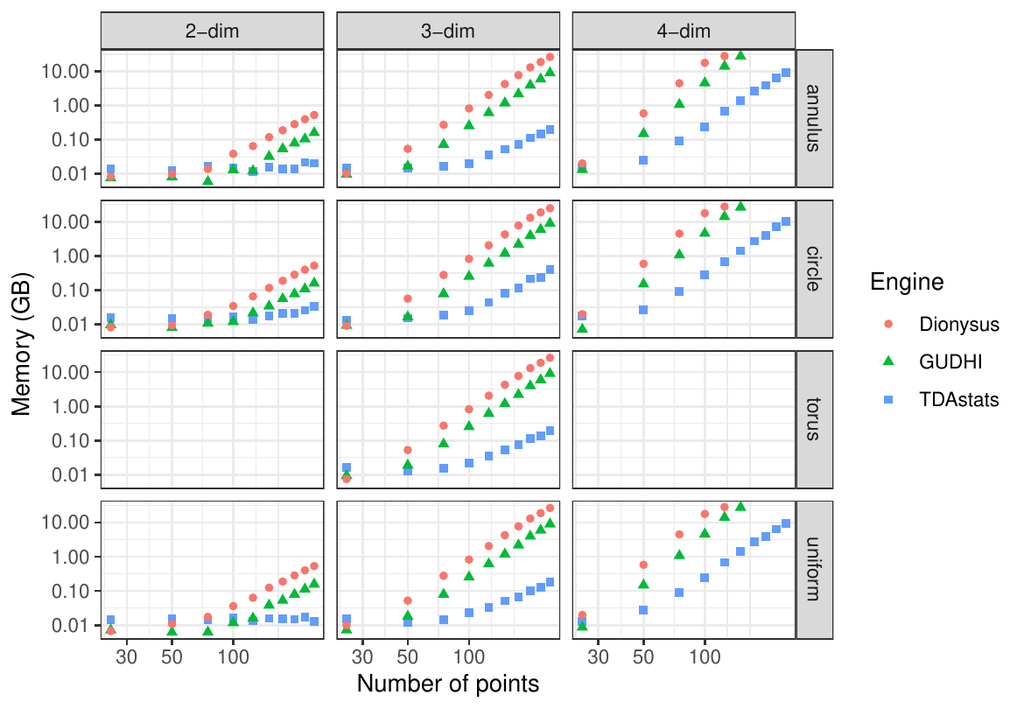

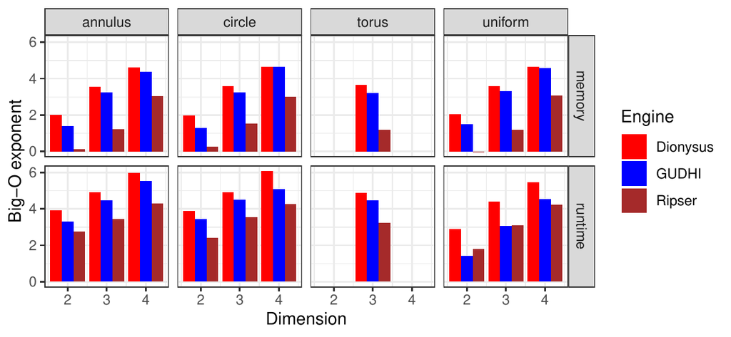

Figure 8: **Big-O exponents for runtime and memory complexity as point cloud size varies.** In the majority of cases, Ripser (and consequently, TDAstats) has the lowest exponent, indicating the slowest growth in complexity as point cloud size increases. Due to shape constraints, torus only has data available in the third dimension.

## 5 Discussion

As persistent homology calculations continue to become a more popular tool to analyze complex multidimensional data, it will be important to understand from a computational perspective which method to use. In this paper, we examined two forms of persistent homology complexes: Vietoris-Rips and alpha complexes. Both algorithms describe topological features through the generation of simplicial complexes. The advantage in saving computational time by choosing a particular algorithm depends on point cloud characteristics.

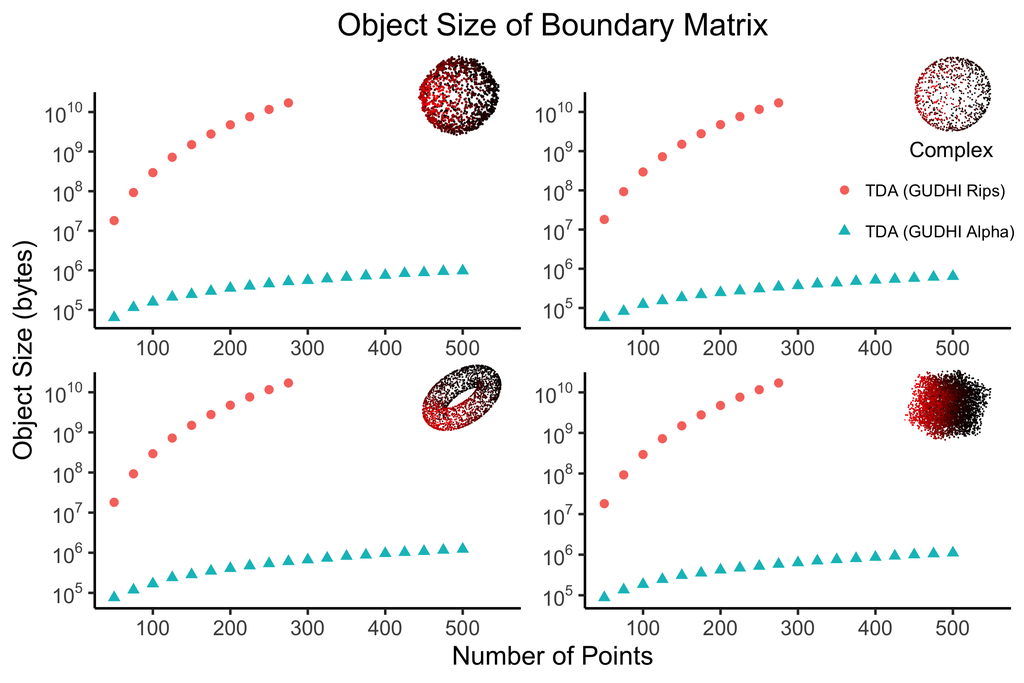

Based on the theoretical complexity and our results, alpha complexes are superior for point clouds with 3 or fewer dimensions. This advantage becomes especially clear at a high number of points. This difference in performance is clear in both runtime and memory use. Interestingly, while alpha complexes had overall less memory use, the memory use varied depending on the shape. Alpha complexes seem to require more memory for noisier data sets such as the annulus when compared to the sphere.

However, without sufficient computational resources, alpha complexes were not usable for point cloud dimensions greater than 3. If a point cloud has more than 3 dimensions, then it could undergo pre-processing with dimension reduction before using alpha complexes. Note, it is possible an algorithm will eventually be developed to enable alpha complex computation of higher-dimensional data. However, if data dimension cannot be reduced without significant information loss, then Vietoris-Rips complexes should be used. It should be stated that if a point cloud is compatible with both complexes, both analyses should be performed as there may be a variation in the persistent homology matrix. This is because alpha complexes satisfy the Nerve Theorem (Edelsbrunner and Mücke 1994), which implies that they are topologically equivalent to the true underlying topology of the dataset; in contrast, Vietoris-Rips complexes only approximate the underlying topology (Hausmann 1996). Among the tested Vietoris-Rips engines, Ripser (wrapped by [*TDAstats*](https://CRAN.R-project.org/package=TDAstats)) has the fastest calculation time. GUDHI and Dionysus (wrapped by [*TDA*](https://CRAN.R-project.org/package=TDA)) significantly fall behind as feature dimension and number of points increase.

On average, Ripser computed the persistent homology of a Vietoris-Rips complex with less memory than either GUDHI or Dionysus. Thus, when efficiency is critical, useRs would likely find [*TDAstats*](https://CRAN.R-project.org/package=TDAstats) the appropriate library. However, [*TDA*](https://CRAN.R-project.org/package=TDA) contains an entire library of features not available in [*TDAstats*](https://CRAN.R-project.org/package=TDAstats). Specifically, [*TDA*](https://CRAN.R-project.org/package=TDA) allows kNN density estimation, kernel density estimation, density-based clustering, and dendrogram visualization, among other useful functionality. When computational resources are plenty, when point clouds are small and low-dimensional, or when the aforementioned functionality is required, [*TDA*](https://CRAN.R-project.org/package=TDA) will likely be more appropriate than [*TDAstats*](https://CRAN.R-project.org/package=TDAstats). Both packages are hosted on CRAN.

While Vietoris-Rips complexes can handle high-dimensional data well, the calculation still significantly slows down when looking for higher dimension features. This is evidenced by the big-O polynomial growth for runtime and memory that have degree less than 4 for most 2-dimensional point clouds, but degree between 4 and 6 for most 4-dimensional point clouds (Figure 8); even higher degree complexities should be expected as point cloud dimension increases. Thus, finding high-dimensional topological features in high-dimensional point clouds remains a challenge. Methods to calculate persistent homology do exist for other simplicial complexes, such as the Delaunay complex and the Witness complex, but, to our knowledge, they are not currently implemented in CRAN packages. Future challenges would be creating and implementing algorithms that reduce the computational complexity of higher-dimensional topological feature calculations for R.

## 6 Acknowledgments

The authors thank Emily Dolson, PhD for assistance with using a high-performance computing node for data collection. JGS was supported by NIH grant R37 CA244613.

### 6.1 Supplementary materials

Supplementary materials are available in addition to this article. It can be downloaded at RJ-2021-033.zip

### 6.2 CRAN packages used

TDA, TDAstats, readr, ggplot2, scatterplot3d, recexcavAAR, deldir, magick, bench, pryr

### 6.3 CRAN Task Views implied by cited packages

ChemPhys, NetworkAnalysis, Phylogenetics, Spatial, TeachingStatistics, WebTechnologies

U. Bauer. Ripser: Efficient computation of vietoris-rips persistence barcodes. *arXiv*, math.AT(1908.02518): 2019.

J. C. Brunson, R. R. Wadhwa and J. G. Scott. *Ggtda: ggplot2-compatible visualization of persistent homology.* 2020. URL https://github.com/rrrlw/ggtda. R package version 0.1.0.

J. M. Chan, G. Carlsson and R. Rabadan. Topology of viral evolution. *Proceedings of the National Academy of Sciences*, 110(46): 18566--18571, 2013. DOI 10.1073/pnas.1313480110.

H. Edelsbrunner and J. Harer. Persistent homology — a survey. *Discrete & Computational Geometry*, 453: 2008. DOI 10.1090/conm/453/08802.

H. Edelsbrunner and E. P. Mücke. Three-dimensional alpha shapes. *ACM Transactions on Graphics*, 13(1): 43–72, 1994. DOI 10.1145/174462.156635.

B. T. Fasy, J. Kim, F. Lecci, C. Maria, D. L. Millman and V. Rouvreau. *TDA: Statistical tools for topological data analysis.* 2019. URL https://CRAN.R-project.org/package=TDA. R package version 1.6.5.

J.-C. Hausmann. On the vietoris-rips complexes and a cohomology theory for metric spaces. In *Prospects in topology (AM-138): Proceedings of a conference in honor of william browder*, Ed F. Quinn pages. 175–188 1996. Princeton, NJ: Princeton University Press. DOI 10.1515/9781400882588-013.

J. Hester. *Bench: High precision timing of r expressions.* 2019. URL https://CRAN.R-project.org/package=bench. R package version 1.0.4.

U. Ligges and M. Mächler. Scatterplot3d - an r package for visualizing multivariate data. *Journal of Statistical Software*, 8(11): 1–20, 2003. URL http://www.jstatsoft.org.

C. Maria, P. Dlotko, V. Rouvreau and M. Glisse. Rips complex. In *GUDHI user and reference manual*, 2016. GUDHI Editorial Board. URL http://gudhi.gforge.inria.fr/doc/latest/.

D. Morozov. *Dionysus.* 2018. URL http://mrzv.org/software/dionysus2.

M. Offroy and L. Duponchel. Topological data analysis: A promising big data exploration tool in biology, analytical chemistry and physical chemistry. *Analytica Chimica Acta*, 910: 1–11, 2016. DOI 10.1016/j.aca.2015.12.037.

J. Ooms. *Magick: Advanced graphics and image-processing in r.* 2019. URL https://CRAN.R-project.org/package=magick. R package version 2.2.

N. Otter, M. A. Porter, U. Tillmann, P. Grindrod and H. A. Harrington. A roadmap for the computation of persistent homology. *EPJ Data Science*, 6(1): 2017. DOI 10.1140/epjds/s13688-017-0109-5.

C. Schmid and B. Serbe. *recexcavAAR: 3D reconstruction of archaeological excavations.* 2017. URL https://CRAN.R-project.org/package=recexcavAAR. R package version 0.3.0.

R. Turner. *Deldir: Delaunay triangulation and dirichlet (voronoi) tessellation.* 2020. URL https://CRAN.R-project.org/package=deldir. R package version 0.1-25.

R. R. Wadhwa, D. F. K. Williamson, A. Dhawan and J. G. Scott. TDAstats: R pipeline for computing persistent homology in topological data analysis. *Journal of Open Source Software*, 3(28): 860, 2018. URL https://doi.org/10.21105/joss.00860.

H. Wickham. *ggplot2: Elegant graphics for data analysis.* Springer-Verlag New York, 2016. URL https://ggplot2.tidyverse.org.

H. Wickham. *Pryr: Tools for computing on the language.* 2018. URL https://CRAN.R-project.org/package=pryr. R package version 0.1.4.

H. Wickham, J. Hester and R. Francois. *Readr: Read rectangular text data.* 2018. URL https://CRAN.R-project.org/package=readr. R package version 1.3.1.